# Beers and Breweries

Clara Mugnai

3/23/2022

Making a shiny app - working with data from a git hub repository data set, converted to a csv for me to use

```r
library(tidyverse)
```

```r
library(leaflet)
library(ggplot2)
library(shinythemes)

rating_df <- read_csv("data/stylereview.csv")
cities_df <- read_csv("data/uscities.csv")
beer_df <- read_csv("data/beer.csv")
```

```
## * `` -> ...1
```

```r
beer_city <- left_join(beer_df, cities_df, by = c("City" = "city")) %>% filter(State == state_id) %>% select(1:11, 17:19)

beer_city <- left_join(beer_city, rating_df, by = c("Style" = "Style")) %>% select(1:13, 17, 18) %>% rename(Style_rating = review_avg)


beer_map2 <- leaflet(beer_city) %>%
  setView(lng = -98.583, lat = 39.833, zoom = 4) %>%
  addTiles() %>%
  addProviderTiles(providers$Wikimedia) %>%
  addMarkers(lng = beer_city$lng, lat = beer_city$lat, clusterOptions = markerClusterOptions(), label = paste("Beer name:", beer_city$Name.x,"<br>", "Brewery name:", beer_city$Name.y))

beer_map2
```

[interactive chart not shown]

- In the app I want a table to pop up where you can pick a city and see type listed as well, to make it clearer.
- Made base shiny app with the front tab as a leaflet with all of the beers and then a table underneath that the person can change for each city. Need to add tabs with styles and plots of the styles.
- Have tabs for both style and brewery - investigate a way to connect the app so you can click on a style or a brewery and be redirected to that tab?

Making static plots by style: want data set that has mean ABV for each type so that lollipop plot can be made where you pick a style or multiple styles and it shows mean ABV as well as the ABV for each one.

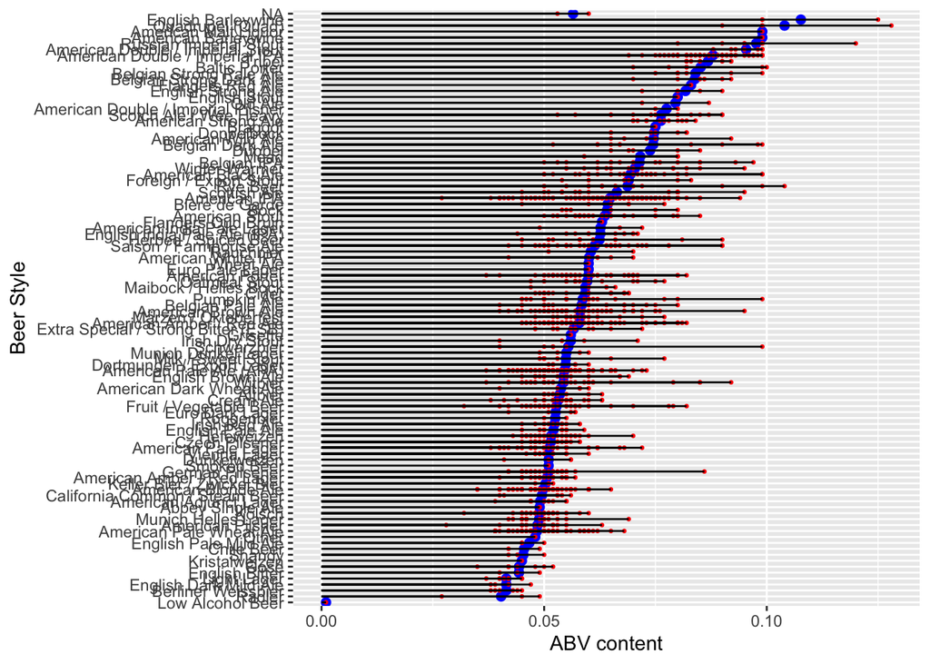

```r
style_df <- beer_city %>% group_by(Style) %>%
  summarise(meanABV = mean(ABV, na.rm = TRUE)) %>%
  ungroup() %>%
  mutate(Style = fct_reorder(Style, meanABV))

ggplot(data = beer_city, aes(x = Style, y = ABV)) +
  geom_point(data = style_df, aes(y = meanABV), color = "Blue", size =2) +
  geom_point(color = "Red", size = .5) +
  geom_segment((aes(x=Style, xend=Style, y=0, yend=ABV))) + coord_flip() + labs(x = "Beer Style", y = "ABV content")
```

```r
beer_city$StyleColor <- cut(beer_city$Style_rating,
                        c(2.1, 3.7,3.8,3.9,4.1), include.lowest = T,
                        labels = c('< 3.7', '3.7-3.8', '3.8-3.9', '3.9-4.1'), na.rm=TRUE)

StyleCol <- colorFactor(c("#BFD3E6", "#9EBCDA", "#8C96C6", "#88419D"), beer_city$StyleColor)

colScale <- scale_colour_manual("Style Rating", breaks = c('< 3.7', '3.7-3.8', '3.8-3.9', '3.9-4.1'),
                                values = c("#BFD3E6", "#9EBCDA", "#8C96C6", "#88419D"))
```

Want to put this plot into a new tab on the shiny app. Have to figure out how to make a new tab and then put this onto it. -Got the input, need to put in reactive data set.

- look into zooming based on the city you choose - problem! I have ideas to fix this but it is taking forever, something to do with leafletProxy and observe

-Now I will put in reactive lollipop plot because I know how to do that.

- also going to add a lollipop plot that compares IBU values across styles
- this runs so I will change the input of the x so the user can choose either IBU or ABV and they are on the same plot, with the axis label changing conditionally. Next time I work on this.
- now have title above the table
- Got it to zoom based on input!!
- Added titles for the plots
- Added a descriptive blurb on first tab with text of what the data set is and the app is doing.
- Switched the style tab to a fluid row layout with columns instead of a sidebar sidepanel layout.
- Added a leaflet map that marks on the large scale a dot cluster where each style appears when users picks styles from the style tab.
- Added a tab where user can choose a brewery
- made choices of two brewery options they pick two outputting
- Made the two table output
- Made plot output for the breweries and angles labels
- corrected clusters and markers and labels for all of the maps
- fixed the zoom so it is adjusting for the two component data set
- added text outputs above the columns with plots and table what brewery it is showing information for
- removed bar charts because they were not useful
- Found and cleaned another dataset with more information per brewery, turned into a csv and read that in so that the app is clean.
- Realized there are no breweries in common between the two data sets so it won’t work and I should look for another.
- Made titles for lollipop charts bigger
- Made the third map show a point even if only one beer
- Made the lines have markers at the end of them so they are easier to use.
- Found another data set with ratings by style and added that to the beer_city data set
- Added a table to the style tab that has the ratings for the styles user has selected
- Fixed style table so it is grouped
- Made labels say what they are showing, and be bold, and be multiple lines, not just slashes between.
- Corrected brewery tab so the map does not resize everytime you change it.
- Colored circles by style rating in the style tab.
- Added a data set with ratings by beer, not just style.
- Changed color scale so it is easier to see on the white background
- Changed marker color in brewery tab to be by style
- Changed the cut offs in my color scale so they change more, right now most beers are in the same category. So an evenly split range might not be in my best interest.
- Fixed fill so you can see markers better
- De-bugged the brewery tab a bit
- Working on coloring the lollipops by the same scale as the leaflet - have them changing for style rating but the color scale does not match.
- Colored dots in lollipop chart to match the circles on the leaflet plot!!
- Changed theme and color so that everything looks good and matches
- Changed colors again because I realized you can’t see the NA’s well on the plot
- Changed name of color scale
- Change whole shiny theme to look more professional

Decisions made:

- Change the input of the x so the user can choose either IBU or ABV and they are on the same plot, with the axis label changing conditionally? Could be good to keep both or could be better to have the user choose one. I think I will keep both for the reasoning that it is one less thing for the user to put in and I think the page can handle it.
- I did all the work to add a huge ratings data set but because the crossover is so limited I think I will have to remove it and find something else to add.

```r
library(shiny)
ui <- fluidPage(theme = shinytheme("cyborg"),
  titlePanel("Breweries and Beers in U.S.A."),
  tabsetPanel(tabPanel("Beer Map",
    sidebarLayout(sidebarPanel(
      strong("Welcome!", style = "color:darkorange"),
      p("- This data set is a compiled list of over 2,000 beers from various breweries spread around the U.S.A."),
      p("- Enjoy navigating these tabs in the top left to compare locations, beer styles, and various breweries."),
      p("- Select inputs from the selections on the left side of the screen and watch the right side change!"),
      p("- The maps can be zoomed in and out further with mouse scrolling or the +/- buttons, and surprises might appear           if you click your mouse in certain places."),
      p("- Finally, scroll down on the pages to make sure you are not missing any cool content."),
      p("Enjoy exploring!", style = "color:darkorange"),
    selectizeInput("citychoice",
                   label = "Choose a City", choices = levels(factor(beer_city$City)),
                   selected = "Austin"), width = 3),
    mainPanel(leafletOutput("leafplot"),
              span(textOutput("tabletitle"), style = "font-size:150%"),
              tableOutput("citybeer")),
   )
  ),
 tabPanel("Styles",
          fluidRow(
            column(selectizeInput("stylechoice",
                           label = "Choose a Style or Multiple", choice = levels(factor(beer_city$Style)),
                           selected = "Belgian IPA", multiple = TRUE), width = 2),
            column(6,
                    plotOutput("lollipop1"),
                   plotOutput("lollipop2")),
            column(4,
                    leafletOutput("leafplot2"),
                   tableOutput("stylerating")),
      )),
 tabPanel("Breweries",
          fluidRow(
            column(selectizeInput("brewerychoice",
                           label = "Choose a Brewery", choice = levels(factor(beer_city$Name.y)),
                           selected = "NorthGate Brewing"),
                   selectizeInput("brewerychoice2",
                            label = "Choose another Brewery", choice = levels(factor(beer_city$Name.y)),
                            selected = "Avery Brewing Company"), width = 2),
            column(3,
                   span(textOutput("tabletitle2"), style = "font-size:150%"),
                   tableOutput("brewery1")),
            column(3,
                   span(textOutput("tabletitle3"), style = "font-size:150%"),
                   tableOutput("brewery2")),
            column(3,
                   leafletOutput("leafplot3")),
          ))
  ))
server <- function(input, output, session) {

   onecity_df <- reactive({beer_city %>% filter(City == input$citychoice) %>% rename("Beer name" = "Name.x", "Brewery" = "Name.y")
   })
   style <- reactive({beer_city %>% filter(Style %in% input$stylechoice)
     })
   style2 <- reactive({beer_city %>% filter(Style %in% input$stylechoice)%>% group_by(Style) %>%
  summarise(meanABV = mean(ABV, na.rm = TRUE)) %>%
  ungroup() %>%
  mutate(Style = fct_reorder(Style, meanABV))
     })
   style3 <- reactive({beer_city %>% filter(Style %in% input$stylechoice)%>% group_by(Style) %>%
  summarise(meanIBU = mean(IBU, na.rm = TRUE)) %>%
  ungroup() %>%
  mutate(Style = fct_reorder(Style, meanIBU))
     })
   style4 <- reactive({beer_city %>% filter(Style %in% input$stylechoice) %>% group_by(Style) %>% summarise(Mean_Rating = mean(Style_rating, na.rm = TRUE)) %>%
  mutate(Style = fct_reorder(Style, Mean_Rating))
     })
   onebrewery_df <- reactive({beer_city %>% filter(Name.y == input$brewerychoice) %>% rename("Beer name" = "Name.x", "Brewery" = "Name.y")
   })
   onebrewery_df2 <- reactive({beer_city %>% filter(Name.y == input$brewerychoice2) %>% rename("Beer name" = "Name.x", "Brewery" = "Name.y")
   })
   both_breweries <- reactive({full_join(onebrewery_df(), onebrewery_df2())
   })


   output$leafplot <- renderLeaflet({
    leaflet(beer_city) %>%
  flyTo(lng = -98.583, lat = 39.833, zoom = 6) %>%
  addTiles() %>%
  addProviderTiles(providers$Wikimedia) %>%
  addCircleMarkers(lng = beer_city$lng, lat = beer_city$lat, clusterOptions = markerClusterOptions(singleMarkerMode = TRUE, color = "Lightpurple"), label = lapply(paste("<strong> Beer name: </strong>", beer_city$Name.x,"<br> <strong> Brewery name: </strong>", beer_city$Name.y), htmltools::HTML))
  })

   observe({
    city <- onecity_df()
    leafletProxy("leafplot") %>% fitBounds(min(city$lng), min(city$lat),
                                        max(city$lng+1/4), max(city$lat+1/4))
  })

  output$tabletitle <- renderText({
    (input$citychoice)
  })

  output$citybeer <- renderTable({
    onecity_df() %>% select(3,7,9)
    })

  output$lollipop1 <- renderPlot({
    ggplot(data = style(), aes(x = Style, y = ABV)) +
  geom_point(data = style2(), aes(y = meanABV), color = "Orange", size = 3) +
  geom_point(aes(color = StyleColor), size = 2) +
  colScale +
  geom_segment((aes(x=Style, xend=Style, y=0, yend=ABV))) +
  coord_flip() +
  labs(x = "Beer Style", y = "ABV content", title = "Average ABV content by Beer Style") + theme_gray() + theme(title=element_text(size=14,face="bold",color = "darkorange3"), axis.title = element_text(size = 12, face = "plain", color = "darkorange3"))
  })

  output$lollipop2 <- renderPlot({
    ggplot(data = style(), aes(x = Style, y = IBU)) +
  geom_point(data = style3(), aes(y = meanIBU), color = "Orange", size = 3) +
  geom_point(aes(color = StyleColor), size = 2) +
  colScale +
  geom_segment((aes(x=Style, xend=Style, y=0, yend=IBU))) +
  coord_flip() +
  labs(x = "Beer Style", y = "IBU content", title = "Average IBU content by Beer Style") + theme_gray()  + theme(title=element_text(size=14,face="bold", color = "darkorange3"), axis.title = element_text(size = 12, face = "plain", color = "darkorange3"))
  })

  output$leafplot2 <- renderLeaflet({
    leaflet(beer_city) %>%
  flyTo(lng = -98.583, lat = 39.833, zoom = 3) %>%
  addTiles() %>%
  addProviderTiles(providers$Wikimedia)
  })

  observe({
    style <- style()
    leafletProxy("leafplot2") %>% clearControls() %>% clearMarkerClusters() %>% addCircleMarkers(lng = style$lng, lat = style$lat, label = lapply(paste( "<strong> Beer name: </strong>", style$Name.x, "<br> <strong> Beer style: </strong>", style$Style, "<br> <strong> Brewery name: </strong>", style$Name.y), htmltools::HTML), color = StyleCol(style$StyleColor), clusterOptions = markerClusterOptions(singleMarkerMode = TRUE), opacity = 2, fillOpacity = .5) %>%
    addLegend('bottomright', pal = StyleCol, values = beer_city$StyleColor, title = 'Style Rating', opacity = 1)

  })

  output$stylerating <- renderTable({
    style4()
    })

  output$tabletitle2 <- renderText({
    (input$brewerychoice)
  })

  output$brewery1 <- renderTable({
    onebrewery_df() %>% select(3,7,9)
  })

  output$tabletitle3 <- renderText({
    (input$brewerychoice2)
  })

  output$brewery2 <- renderTable({
    onebrewery_df2() %>% select(3,7,9)
  })

  output$leafplot3 <- renderLeaflet({
    leaflet(beer_city) %>%
  flyTo(lng = -98.583, lat = 39.833, zoom = 3) %>%
  addTiles() %>%
  addProviderTiles(providers$Wikimedia)
  })

  observe({
    brewery <- both_breweries()
    style <- style()
     leafletProxy("leafplot3") %>% clearControls() %>% clearMarkers() %>% clearMarkerClusters() %>% fitBounds(min(brewery$lng), min(brewery$lat), max(brewery$lng+1/2), max(brewery$lat-1/2)) %>% addCircleMarkers(lng = brewery$lng, lat = brewery$lat, label = lapply(paste( "<strong> Beer name: </strong>", brewery$`Beer name`, "<br> <strong> Beer style: </strong>", brewery$Style, "<br> <strong> Brewery name: </strong>", brewery$Brewery), htmltools::HTML), clusterOptions = markerClusterOptions(singleMarkerMode = TRUE), color = StyleCol(brewery$StyleColor), opacity = 2, fillOpacity = .5) %>% addLegend('topright', pal = StyleCol, values = beer_city$StyleColor, title = 'Style Rating', opacity = 1)
  })
}

shinyApp(ui, server)
```

[output not shown]

[output not shown]

Shiny applications not supported in static R Markdown documents